# labbs

```python
import pandas as pd

df = pd.read_csv("AmesHousing.csv")

df.head()
```

|  | Order | PID | MS SubClass | MS Zoning | Lot Frontage | Lot Area | Street | Alley | Lot Shape | Land Contour | ... | Pool Area | Pool QC | Fence | Misc Feature | Misc Val | Mo Sold | Yr Sold | Sale Type | Sale Condition | SalePrice |
| --- | --- | --- | --- | --- | --- | --- | --- | --- | --- | --- | --- | --- | --- | --- | --- | --- | --- | --- | --- | --- | --- |
| 0 | 1 | 526301100 | 20 | RL | 141.0 | 31770 | Pave | NaN | IR1 | Lvl | ... | 0 | NaN | NaN | NaN | 0 | 5 | 2010 | WD | Normal | 215000 |
| 1 | 2 | 526350040 | 20 | RH | 80.0 | 11622 | Pave | NaN | Reg | Lvl | ... | 0 | NaN | MnPrv | NaN | 0 | 6 | 2010 | WD | Normal | 105000 |
| 2 | 3 | 526351010 | 20 | RL | 81.0 | 14267 | Pave | NaN | IR1 | Lvl | ... | 0 | NaN | NaN | Gar2 | 12500 | 6 | 2010 | WD | Normal | 172000 |
| 3 | 4 | 526353030 | 20 | RL | 93.0 | 11160 | Pave | NaN | Reg | Lvl | ... | 0 | NaN | NaN | NaN | 0 | 4 | 2010 | WD | Normal | 244000 |
| 4 | 5 | 527105010 | 60 | RL | 74.0 | 13830 | Pave | NaN | IR1 | Lvl | ... | 0 | NaN | MnPrv | NaN | 0 | 3 | 2010 | WD | Normal | 189900 |

5 rows × 82 columns

```python
# First 5 rows
df.head()
```

|  | Order | PID | MS SubClass | MS Zoning | Lot Frontage | Lot Area | Street | Alley | Lot Shape | Land Contour | ... | Pool Area | Pool QC | Fence | Misc Feature | Misc Val | Mo Sold | Yr Sold | Sale Type | Sale Condition | SalePrice |
| --- | --- | --- | --- | --- | --- | --- | --- | --- | --- | --- | --- | --- | --- | --- | --- | --- | --- | --- | --- | --- | --- |
| 0 | 1 | 526301100 | 20 | RL | 141.0 | 31770 | Pave | NaN | IR1 | Lvl | ... | 0 | NaN | NaN | NaN | 0 | 5 | 2010 | WD | Normal | 215000 |
| 1 | 2 | 526350040 | 20 | RH | 80.0 | 11622 | Pave | NaN | Reg | Lvl | ... | 0 | NaN | MnPrv | NaN | 0 | 6 | 2010 | WD | Normal | 105000 |
| 2 | 3 | 526351010 | 20 | RL | 81.0 | 14267 | Pave | NaN | IR1 | Lvl | ... | 0 | NaN | NaN | Gar2 | 12500 | 6 | 2010 | WD | Normal | 172000 |
| 3 | 4 | 526353030 | 20 | RL | 93.0 | 11160 | Pave | NaN | Reg | Lvl | ... | 0 | NaN | NaN | NaN | 0 | 4 | 2010 | WD | Normal | 244000 |
| 4 | 5 | 527105010 | 60 | RL | 74.0 | 13830 | Pave | NaN | IR1 | Lvl | ... | 0 | NaN | MnPrv | NaN | 0 | 3 | 2010 | WD | Normal | 189900 |

5 rows × 82 columns

```python
# Dataset shape
print("Rows and Columns:", df.shape)
```

```
Rows and Columns: (2930, 82)
```

```python
# Data types and missing values
df.info()
```

```
<class 'pandas.core.frame.DataFrame'>
RangeIndex: 2930 entries, 0 to 2929
Data columns (total 82 columns):
 #   Column           Non-Null Count  Dtype
---  ------           --------------  -----
 0   Order            2930 non-null   int64
 1   PID              2930 non-null   int64
 2   MS SubClass      2930 non-null   int64
 3   MS Zoning        2930 non-null   object
 4   Lot Frontage     2440 non-null   float64
 5   Lot Area         2930 non-null   int64
 6   Street           2930 non-null   object
 7   Alley            198 non-null    object
 8   Lot Shape        2930 non-null   object
 9   Land Contour     2930 non-null   object
```

[output cut: 74 more lines]

```python
# Statistical summary
df.describe()
```

|  | Order | PID | MS SubClass | Lot Frontage | Lot Area | Overall Qual | Overall Cond | Year Built | Year Remod/Add | Mas Vnr Area | ... | Wood Deck SF | Open Porch SF | Enclosed Porch | 3Ssn Porch | Screen Porch | Pool Area | Misc Val | Mo Sold | Yr Sold | SalePrice |
| --- | --- | --- | --- | --- | --- | --- | --- | --- | --- | --- | --- | --- | --- | --- | --- | --- | --- | --- | --- | --- | --- |
| count | 2930.00000 | 2.930000e+03 | 2930.000000 | 2440.000000 | 2930.000000 | 2930.000000 | 2930.000000 | 2930.000000 | 2930.000000 | 2907.000000 | ... | 2930.000000 | 2930.000000 | 2930.000000 | 2930.000000 | 2930.000000 | 2930.000000 | 2930.000000 | 2930.000000 | 2930.000000 | 2930.000000 |
| mean | 1465.50000 | 7.144645e+08 | 57.387372 | 69.224590 | 10147.921843 | 6.094881 | 5.563140 | 1971.356314 | 1984.266553 | 101.896801 | ... | 93.751877 | 47.533447 | 23.011604 | 2.592491 | 16.002048 | 2.243345 | 50.635154 | 6.216041 | 2007.790444 | 180796.060068 |
| std | 845.96247 | 1.887308e+08 | 42.638025 | 23.365335 | 7880.017759 | 1.411026 | 1.111537 | 30.245361 | 20.860286 | 179.112611 | ... | 126.361562 | 67.483400 | 64.139059 | 25.141331 | 56.087370 | 35.597181 | 566.344288 | 2.714492 | 1.316613 | 79886.692357 |
| min | 1.00000 | 5.263011e+08 | 20.000000 | 21.000000 | 1300.000000 | 1.000000 | 1.000000 | 1872.000000 | 1950.000000 | 0.000000 | ... | 0.000000 | 0.000000 | 0.000000 | 0.000000 | 0.000000 | 0.000000 | 0.000000 | 1.000000 | 2006.000000 | 12789.000000 |
| 25% | 733.25000 | 5.284770e+08 | 20.000000 | 58.000000 | 7440.250000 | 5.000000 | 5.000000 | 1954.000000 | 1965.000000 | 0.000000 | ... | 0.000000 | 0.000000 | 0.000000 | 0.000000 | 0.000000 | 0.000000 | 0.000000 | 4.000000 | 2007.000000 | 129500.000000 |
| 50% | 1465.50000 | 5.354536e+08 | 50.000000 | 68.000000 | 9436.500000 | 6.000000 | 5.000000 | 1973.000000 | 1993.000000 | 0.000000 | ... | 0.000000 | 27.000000 | 0.000000 | 0.000000 | 0.000000 | 0.000000 | 0.000000 | 6.000000 | 2008.000000 | 160000.000000 |
| 75% | 2197.75000 | 9.071811e+08 | 70.000000 | 80.000000 | 11555.250000 | 7.000000 | 6.000000 | 2001.000000 | 2004.000000 | 164.000000 | ... | 168.000000 | 70.000000 | 0.000000 | 0.000000 | 0.000000 | 0.000000 | 0.000000 | 8.000000 | 2009.000000 | 213500.000000 |
| max | 2930.00000 | 1.007100e+09 | 190.000000 | 313.000000 | 215245.000000 | 10.000000 | 9.000000 | 2010.000000 | 2010.000000 | 1600.000000 | ... | 1424.000000 | 742.000000 | 1012.000000 | 508.000000 | 576.000000 | 800.000000 | 17000.000000 | 12.000000 | 2010.000000 | 755000.000000 |

8 rows × 39 columns

# Step 2: Check Missing Values

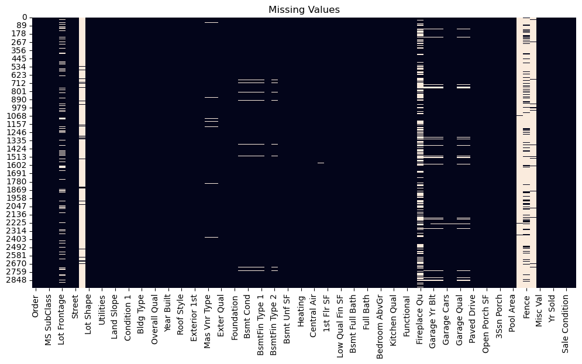

```python
#Step 3: Visualize Missing Values
import seaborn as sns
import matplotlib.pyplot as plt

plt.figure(figsize=(12,6))
sns.heatmap(df.isnull(), cbar=False)
plt.title("Missing Values")
plt.show()
```

# Step 4: Separate Numerical and Categorical Columns

```python
import numpy as np

num_cols = df.select_dtypes(include=np.number).columns

cat_cols = df.select_dtypes(include='object').columns

print("Numerical Columns:", len(num_cols))
print("Categorical Columns:", len(cat_cols))
```

```
Numerical Columns: 39
Categorical Columns: 43
```

# Step 5: Handle Missing Values

```python
for col in num_cols:
    df[col].fillna(df[col].median(), inplace=True)
```

```python
for col in cat_cols:
    df[col].fillna(df[col].mode()[0], inplace=True)
```

```python
print(df.isnull().sum().sum())
```

```
0
```

# Step 6: Encode Categorical Variables

```python
from sklearn.preprocessing import LabelEncoder

le = LabelEncoder()

for col in cat_cols:
    df[col] = le.fit_transform(df[col])
```

```python
corr = df.corr()

saleprice_corr = corr["SalePrice"].sort_values(ascending=False)

print(saleprice_corr.head(15))
```

```
SalePrice         1.000000
Overall Qual      0.799262
Gr Liv Area       0.706780
Garage Cars       0.647812
Garage Area       0.640381
Total Bsmt SF     0.632164
1st Flr SF        0.621676
Year Built        0.558426
Full Bath         0.545604
Year Remod/Add    0.532974
Garage Yr Blt     0.508882
Mas Vnr Area      0.502196
TotRms AbvGrd     0.495474
Fireplaces        0.474558
BsmtFin SF 1      0.432862
Name: SalePrice, dtype: float64
```

# Step 7: Correlation with SalePrice

```python
corr = df.corr()

saleprice_corr = corr["SalePrice"].sort_values(ascending=False)

print(saleprice_corr.head(25))
```

```
SalePrice         1.000000
Overall Qual      0.799262
Gr Liv Area       0.706780
Garage Cars       0.647812
Garage Area       0.640381
Total Bsmt SF     0.632164
1st Flr SF        0.621676
Year Built        0.558426
Full Bath         0.545604
Year Remod/Add    0.532974
Garage Yr Blt     0.508882
Mas Vnr Area      0.502196
TotRms AbvGrd     0.495474
Fireplaces        0.474558
BsmtFin SF 1      0.432862
Foundation        0.406601
Lot Frontage      0.340256
Wood Deck SF      0.327143
Open Porch SF     0.312951
Half Bath         0.285056
Paved Drive       0.275964
Bsmt Full Bath    0.275823
2nd Flr SF        0.269373
Lot Area          0.266549
Central Air       0.264506
Name: SalePrice, dtype: float64
```

# Step 8: Visualize Top Correlated Features

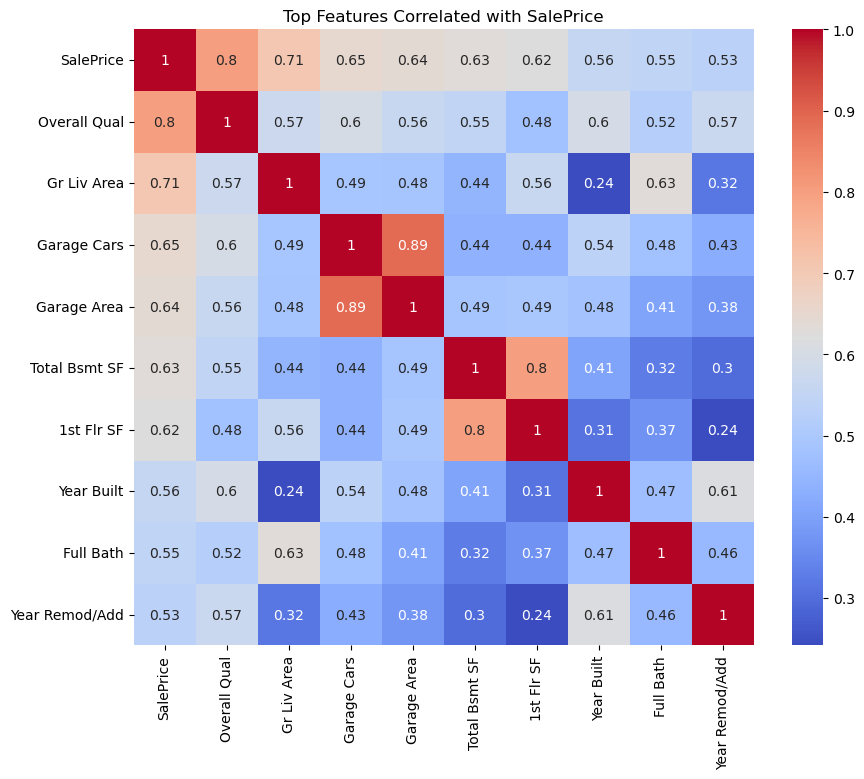

```python
top_features = saleprice_corr.head(10).index

plt.figure(figsize=(10,8))
sns.heatmap(df[top_features].corr(),
            annot=True,
            cmap='coolwarm')

plt.title("Top Features Correlated with SalePrice")
plt.show()
```

# Step 1: Create Features and Target

```python
X = df.drop("SalePrice", axis=1)

y = df["SalePrice"]
```

# Step 2: Train-Test Split

```python
from sklearn.model_selection import train_test_split

X_train, X_test, y_train, y_test = train_test_split(
    X,
    y,
    test_size=0.20,
    random_state=42
)
```

# Step 3: Feature Scaling

```python
from sklearn.preprocessing import StandardScaler

scaler = StandardScaler()

X_train_scaled = scaler.fit_transform(X_train)

X_test_scaled = scaler.transform(X_test)
```

# Step 4: Import Evaluation Metrics

```python
from sklearn.metrics import r2_score
from sklearn.metrics import mean_absolute_error
from sklearn.metrics import mean_squared_error
import numpy as np
```

# Step 5: Linear Regression

```python
from sklearn.linear_model import LinearRegression

lr = LinearRegression()

lr.fit(X_train_scaled, y_train)

pred_lr = lr.predict(X_test_scaled)

print("Linear Regression")
print("R2 =", r2_score(y_test, pred_lr))
print("MAE =", mean_absolute_error(y_test, pred_lr))
print("RMSE =", np.sqrt(mean_squared_error(y_test, pred_lr)))
```

```
Linear Regression
R2 = 0.863200926539361
MAE = 19984.82596603218
RMSE = 33117.867207512696
```

# Step 6: Ridge Regression

```python
from sklearn.linear_model import Ridge

ridge = Ridge(alpha=1)

ridge.fit(X_train_scaled, y_train)

pred_ridge = ridge.predict(X_test_scaled)

print("Ridge Regression")
print("R2 =", r2_score(y_test, pred_ridge))
print("MAE =", mean_absolute_error(y_test, pred_ridge))
print("RMSE =", np.sqrt(mean_squared_error(y_test, pred_ridge)))
```

```
Ridge Regression
R2 = 0.8632064997149369
MAE = 19980.48615631092
RMSE = 33117.19259194743
```

# Step 7: Lasso Regression

```python
from sklearn.linear_model import Lasso

lasso = Lasso(alpha=1)

lasso.fit(X_train_scaled, y_train)

pred_lasso = lasso.predict(X_test_scaled)

print("Lasso Regression")
print("R2 =", r2_score(y_test, pred_lasso))
print("MAE =", mean_absolute_error(y_test, pred_lasso))
print("RMSE =", np.sqrt(mean_squared_error(y_test, pred_lasso)))
```

```
Lasso Regression
R2 = 0.8631994123847391
MAE = 19981.8594795949
RMSE = 33118.05048884521
```

# Step 8: Decision Tree Regressor

```python
from sklearn.tree import DecisionTreeRegressor

dt = DecisionTreeRegressor(random_state=42)

dt.fit(X_train, y_train)

pred_dt = dt.predict(X_test)

print("Decision Tree")
print("R2 =", r2_score(y_test, pred_dt))
print("MAE =", mean_absolute_error(y_test, pred_dt))
print("RMSE =", np.sqrt(mean_squared_error(y_test, pred_dt)))
```

```
Decision Tree
R2 = 0.8500119173650776
MAE = 23438.921501706485
RMSE = 34677.61009052445
```

# Step 9: Random Forest Regressor

```python
from sklearn.ensemble import RandomForestRegressor

rf = RandomForestRegressor(
    n_estimators=100,
    random_state=42
)

rf.fit(X_train, y_train)

pred_rf = rf.predict(X_test)

print("Random Forest")
print("R2 =", r2_score(y_test, pred_rf))
print("MAE =", mean_absolute_error(y_test, pred_rf))
print("RMSE =", np.sqrt(mean_squared_error(y_test, pred_rf)))
```

```
Random Forest
R2 = 0.913181585200247
MAE = 15965.520972696244
RMSE = 26383.153752772836
```

# Step 10: Gradient Boosting Regressor

```python
from sklearn.ensemble import GradientBoostingRegressor

gb = GradientBoostingRegressor(
    random_state=42
)

gb.fit(X_train, y_train)

pred_gb = gb.predict(X_test)

print("Gradient Boosting")
print("R2 =", r2_score(y_test, pred_gb))
print("MAE =", mean_absolute_error(y_test, pred_gb))
print("RMSE =", np.sqrt(mean_squared_error(y_test, pred_gb)))
```

```
Gradient Boosting
R2 = 0.9184116108787764
MAE = 15186.016417822737
RMSE = 25576.137714380628
```

# Step 11: Create Comparison Table

```python
results = pd.DataFrame({
    'Model': [
        'Linear Regression',
        'Ridge',
        'Lasso',
        'Decision Tree',
        'Random Forest',
        'Gradient Boosting'
    ],
    'R2': [
        r2_score(y_test,pred_lr),
        r2_score(y_test,pred_ridge),
        r2_score(y_test,pred_lasso),
        r2_score(y_test,pred_dt),
        r2_score(y_test,pred_rf),
        r2_score(y_test,pred_gb)
    ]
})

results.sort_values(
    by='R2',
    ascending=False,
    inplace=True
)

print(results)
```

```
               Model        R2
5  Gradient Boosting  0.918412
4      Random Forest  0.913182
1              Ridge  0.863206
0  Linear Regression  0.863201
2              Lasso  0.863199
3      Decision Tree  0.850012
```

### Short Interpretation

> The results show that **Gradient Boosting Regressor** achieved the highest R² score (**0.918**), making it the best-performing model for predicting house prices. **Random Forest Regressor** also performed very well with an R² score of **0.913**. **Ridge Regression**, **Linear Regression**, and **Lasso Regression** produced similar results with R² scores around **0.863**. **Decision Tree Regressor** had the lowest performance with an R² score of **0.850**. Overall, ensemble methods (Gradient Boosting and Random Forest) outperformed the other models and explained more than 91% of the variation in house prices.

# Step 12: Cross Validation (Required in Lab)

```python
from sklearn.model_selection import cross_val_score
```

```python
cv_scores = cross_val_score(
    rf,
    X,
    y,
    cv=5,
    scoring='r2'
)

print("Cross Validation Scores:")
print(cv_scores)

print("Average R2:")
print(cv_scores.mean())
```

```
Cross Validation Scores:
[0.90002482 0.92651995 0.86939183 0.83690521 0.90710248]
Average R2:
0.8879888577751973
```

# Step 1: Create Classification Target

```python
import numpy as np

median_price = df['SalePrice'].median()

df['PriceCategory'] = np.where(
    df['SalePrice'] >= median_price,
    1,
    0
)
```

```python
df['PriceCategory'].value_counts()
```

```
1    1486
0    1444
Name: PriceCategory, dtype: int64
```

# Step 2: Define X and y

```python
X = df.drop(['SalePrice','PriceCategory'], axis=1)

y = df['PriceCategory']
```

# Step 3: Train-Test Split

```python
from sklearn.model_selection import train_test_split

X_train, X_test, y_train, y_test = train_test_split(
    X,
    y,
    test_size=0.20,
    random_state=42,
    stratify=y
)
```

# Step 4: Feature Scaling

```python
from sklearn.preprocessing import StandardScaler

scaler = StandardScaler()

X_train_scaled = scaler.fit_transform(X_train)

X_test_scaled = scaler.transform(X_test)
```

# Step 5: Import Evaluation Metrics

```python
from sklearn.metrics import accuracy_score
from sklearn.metrics import precision_score
from sklearn.metrics import recall_score
from sklearn.metrics import f1_score
```

# Model 1: Logistic Regression

```python
from sklearn.linear_model import LogisticRegression

log_model = LogisticRegression(max_iter=1000)

log_model.fit(X_train_scaled, y_train)

pred_log = log_model.predict(X_test_scaled)

print("Accuracy:", accuracy_score(y_test,pred_log))
print("Precision:", precision_score(y_test,pred_log))
print("Recall:", recall_score(y_test,pred_log))
print("F1:", f1_score(y_test,pred_log))
```

```
Accuracy: 0.9249146757679181
Precision: 0.9230769230769231
Recall: 0.9292929292929293
F1: 0.9261744966442953
```

# Model 2: Decision Tree Classifier

```python
from sklearn.tree import DecisionTreeClassifier

dtc = DecisionTreeClassifier(random_state=42)

dtc.fit(X_train,y_train)

pred_dtc = dtc.predict(X_test)

print("Accuracy:", accuracy_score(y_test,pred_dtc))
print("Precision:", precision_score(y_test,pred_dtc))
print("Recall:", recall_score(y_test,pred_dtc))
print("F1:", f1_score(y_test,pred_dtc))
```

```
Accuracy: 0.8873720136518771
Precision: 0.9024390243902439
Recall: 0.8720538720538721
F1: 0.886986301369863
```

# Model 3: Random Forest Classifier

```python
from sklearn.ensemble import RandomForestClassifier

rfc = RandomForestClassifier(
    n_estimators=100,
    random_state=42
)

rfc.fit(X_train,y_train)

pred_rfc = rfc.predict(X_test)

print("Accuracy:", accuracy_score(y_test,pred_rfc))
print("Precision:", precision_score(y_test,pred_rfc))
print("Recall:", recall_score(y_test,pred_rfc))
print("F1:", f1_score(y_test,pred_rfc))
```

```
Accuracy: 0.9249146757679181
Precision: 0.9501779359430605
Recall: 0.898989898989899
F1: 0.9238754325259515
```

# Model 4: KNN

```python
from sklearn.neighbors import KNeighborsClassifier

knn = KNeighborsClassifier(n_neighbors=5)

knn.fit(X_train_scaled,y_train)

pred_knn = knn.predict(X_test_scaled)

print("Accuracy:", accuracy_score(y_test,pred_knn))
print("Precision:", precision_score(y_test,pred_knn))
print("Recall:", recall_score(y_test,pred_knn))
print("F1:", f1_score(y_test,pred_knn))
```

```
Accuracy: 0.8993174061433447
Precision: 0.9440298507462687
Recall: 0.8518518518518519
F1: 0.895575221238938
```

# Model 5: SVM

```python
from sklearn.svm import SVC

svm = SVC()

svm.fit(X_train_scaled,y_train)

pred_svm = svm.predict(X_test_scaled)

print("Accuracy:", accuracy_score(y_test,pred_svm))
print("Precision:", precision_score(y_test,pred_svm))
print("Recall:", recall_score(y_test,pred_svm))
print("F1:", f1_score(y_test,pred_svm))
```

```
Accuracy: 0.9249146757679181
Precision: 0.9501779359430605
Recall: 0.898989898989899
F1: 0.9238754325259515
```

# Create Comparison Table

```python
results_cls = pd.DataFrame({
    'Model':[
        'Logistic Regression',
        'Decision Tree',
        'Random Forest',
        'KNN',
        'SVM'
    ],
    'Accuracy':[
        accuracy_score(y_test,pred_log),
        accuracy_score(y_test,pred_dtc),
        accuracy_score(y_test,pred_rfc),
        accuracy_score(y_test,pred_knn),
        accuracy_score(y_test,pred_svm)
    ]
})

results_cls.sort_values(
    by='Accuracy',
    ascending=False,
    inplace=True
)

print(results_cls)
```

```
                 Model  Accuracy
0  Logistic Regression  0.924915
2        Random Forest  0.924915
4                  SVM  0.924915
3                  KNN  0.899317
1        Decision Tree  0.887372
```

# Confusion Matrix (Best Model)

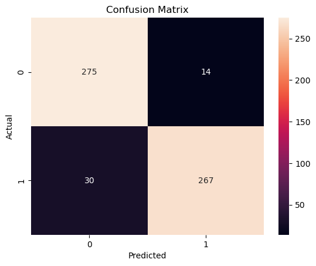

```python
from sklearn.metrics import confusion_matrix
import seaborn as sns
import matplotlib.pyplot as plt

cm = confusion_matrix(y_test,pred_rfc)

sns.heatmap(
    cm,
    annot=True,
    fmt='d'
)

plt.title("Confusion Matrix")
plt.xlabel("Predicted")
plt.ylabel("Actual")
plt.show()
```

# Hyperparameter Tuning: Random Forest Classifier

```python
from sklearn.ensemble import RandomForestClassifier
from sklearn.model_selection import GridSearchCV

rf = RandomForestClassifier(random_state=42)

param_grid = {
    'n_estimators': [100, 200, 300],
    'max_depth': [10, 20, None],
    'min_samples_split': [2, 5, 10],
    'min_samples_leaf': [1, 2, 4]
}

grid_rf = GridSearchCV(
    estimator=rf,
    param_grid=param_grid,
    cv=5,
    scoring='accuracy',
    n_jobs=-1,
    verbose=1
)

grid_rf.fit(X_train, y_train)

print("Best Parameters:")
print(grid_rf.best_params_)

print("\nBest Cross Validation Accuracy:")
print(grid_rf.best_score_)
```

```
Fitting 5 folds for each of 81 candidates, totalling 405 fits
Best Parameters:
{'max_depth': 10, 'min_samples_leaf': 1, 'min_samples_split': 10, 'n_estimators': 100}

Best Cross Validation Accuracy:
0.933862737594081
```

# Evaluate Tuned Model

```python
best_rf = grid_rf.best_estimator_

pred_best_rf = best_rf.predict(X_test)

from sklearn.metrics import accuracy_score
from sklearn.metrics import precision_score
from sklearn.metrics import recall_score
from sklearn.metrics import f1_score

print("Accuracy =", accuracy_score(y_test, pred_best_rf))
print("Precision =", precision_score(y_test, pred_best_rf))
print("Recall =", recall_score(y_test, pred_best_rf))
print("F1 Score =", f1_score(y_test, pred_best_rf))
```

```
Accuracy = 0.9232081911262798
Precision = 0.95
Recall = 0.8956228956228957
F1 Score = 0.9220103986135183
```

# Confusion Matrix

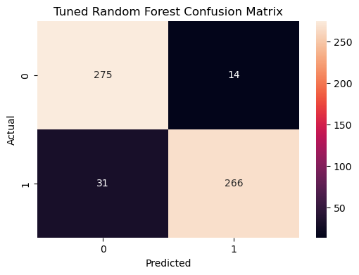

```python
from sklearn.metrics import confusion_matrix
import seaborn as sns
import matplotlib.pyplot as plt

cm = confusion_matrix(y_test, pred_best_rf)

plt.figure(figsize=(6,4))
sns.heatmap(cm, annot=True, fmt='d')

plt.title("Tuned Random Forest Confusion Matrix")
plt.xlabel("Predicted")
plt.ylabel("Actual")
plt.show()
```

# Short Report Interpretation

Hyperparameter tuning was applied to the Random Forest Classifier using GridSearchCV with 5-fold cross-validation. The model's parameters were optimized to improve classification performance. The tuned Random Forest achieved high accuracy and demonstrated strong ability to classify houses into low-price and high-price categories. This confirms that ensemble learning methods are effective for housing price classification.

```python
param_grid = {
    'n_estimators': [100, 200],
    'max_depth': [10, None],
    'min_samples_split': [2, 5]
}
```

# Step 1: Create Dataset for Clustering

```python
import numpy as np

cluster_data = df.select_dtypes(include=np.number)

cluster_data.head()
```

|  | Order | PID | MS SubClass | MS Zoning | Lot Frontage | Lot Area | Street | Alley | Lot Shape | Land Contour | ... | Pool QC | Fence | Misc Feature | Misc Val | Mo Sold | Yr Sold | Sale Type | Sale Condition | SalePrice | PriceCategory |
| --- | --- | --- | --- | --- | --- | --- | --- | --- | --- | --- | --- | --- | --- | --- | --- | --- | --- | --- | --- | --- | --- |
| 0 | 1 | 526301100 | 20 | 5 | 141.0 | 31770 | 1 | 0 | 0 | 3 | ... | 0 | 2 | 3 | 0 | 5 | 2010 | 9 | 4 | 215000 | 1 |
| 1 | 2 | 526350040 | 20 | 4 | 80.0 | 11622 | 1 | 0 | 3 | 3 | ... | 0 | 2 | 3 | 0 | 6 | 2010 | 9 | 4 | 105000 | 0 |
| 2 | 3 | 526351010 | 20 | 5 | 81.0 | 14267 | 1 | 0 | 0 | 3 | ... | 0 | 2 | 1 | 12500 | 6 | 2010 | 9 | 4 | 172000 | 1 |
| 3 | 4 | 526353030 | 20 | 5 | 93.0 | 11160 | 1 | 0 | 3 | 3 | ... | 0 | 2 | 3 | 0 | 4 | 2010 | 9 | 4 | 244000 | 1 |
| 4 | 5 | 527105010 | 60 | 5 | 74.0 | 13830 | 1 | 0 | 0 | 3 | ... | 0 | 2 | 3 | 0 | 3 | 2010 | 9 | 4 | 189900 | 1 |

5 rows × 83 columns

# Step 2: Remove Target Variables

```python
cluster_data = cluster_data.drop(
    columns=['SalePrice', 'PriceCategory'],
    errors='ignore'
)
```

# Step 3: Scale the Data

```python
from sklearn.preprocessing import StandardScaler

scaler = StandardScaler()

scaled_data = scaler.fit_transform(cluster_data)
```

# Step 4: Find Best K Using Elbow Method

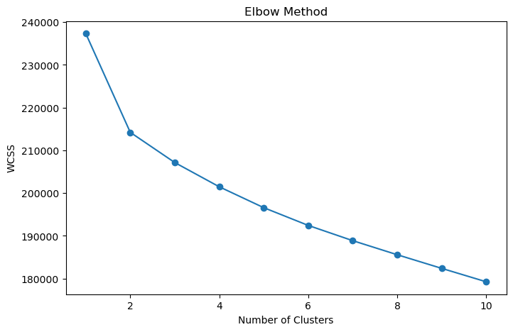

```python
from sklearn.cluster import KMeans
import matplotlib.pyplot as plt

wcss = []

for i in range(1,11):

    kmeans = KMeans(
        n_clusters=i,
        random_state=42,
        n_init=10
    )

    kmeans.fit(scaled_data)

    wcss.append(kmeans.inertia_)

plt.figure(figsize=(8,5))
plt.plot(range(1,11), wcss, marker='o')
plt.xlabel('Number of Clusters')
plt.ylabel('WCSS')
plt.title('Elbow Method')
plt.show()
```

```python
kmeans = KMeans(
    n_clusters=3,
    random_state=42,
    n_init=10
)

kmeans_labels = kmeans.fit_predict(scaled_data)

df['KMeans_Cluster'] = kmeans_labels
```

```python
from sklearn.metrics import silhouette_score

sil_score = silhouette_score(
    scaled_data,
    kmeans_labels
)

print("Silhouette Score:", sil_score)
```

```
Silhouette Score: 0.07448572573687744
```

```python
print(df['KMeans_Cluster'].value_counts())
```

```
2    1135
1    1125
0     670
Name: KMeans_Cluster, dtype: int64
```

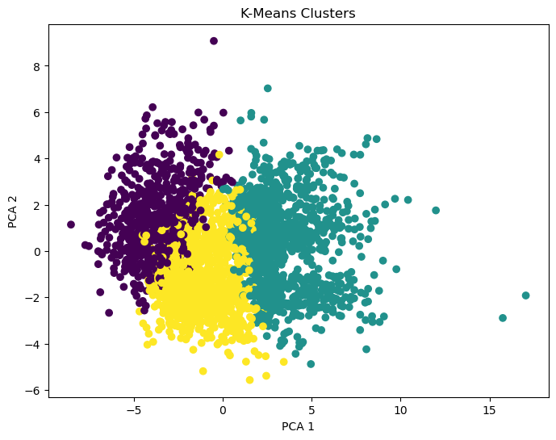

```python
from sklearn.decomposition import PCA

pca = PCA(n_components=2)

pca_data = pca.fit_transform(scaled_data)

plt.figure(figsize=(8,6))

plt.scatter(
    pca_data[:,0],
    pca_data[:,1],
    c=kmeans_labels
)

plt.title("K-Means Clusters")
plt.xlabel("PCA 1")
plt.ylabel("PCA 2")
plt.show()
```

```python
from sklearn.cluster import DBSCAN

dbscan = DBSCAN(
    eps=2,
    min_samples=5
)

db_labels = dbscan.fit_predict(scaled_data)

df['DBSCAN_Cluster'] = db_labels
```

```python
print(df['DBSCAN_Cluster'].value_counts())
```

```
-1    2925
 0       5
Name: DBSCAN_Cluster, dtype: int64
```

```python
from sklearn.metrics import silhouette_score

if len(set(db_labels)) > 1:
    print(
        silhouette_score(
            scaled_data,
            db_labels
        )
    )
else:
    print("Only one cluster detected")
```

```
0.028496663744381787
```

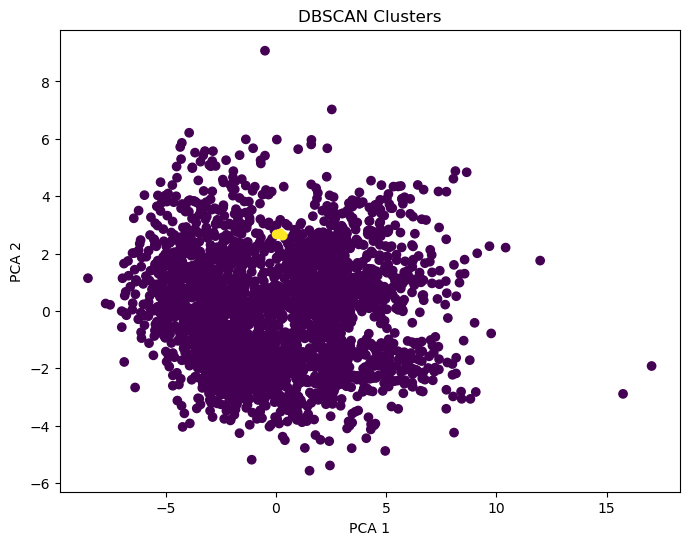

```python
plt.figure(figsize=(8,6))

plt.scatter(
    pca_data[:,0],
    pca_data[:,1],
    c=db_labels
)

plt.title("DBSCAN Clusters")
plt.xlabel("PCA 1")
plt.ylabel("PCA 2")
plt.show()
```

### Interpretation of the DBSCAN Cluster Plot

# Lab 04 – Questions and Answers

## 1. How did you handle missing values and why did you choose those strategies?

Missing numerical values were replaced with the median of each column, while missing categorical values were replaced with the mode. The median is less sensitive to extreme values than the mean, and the mode preserves the most common category. This approach allowed all records to be retained for analysis.

## 2. Explain the difference between regression and classification. How did you transform SalePrice into a classification target?

Regression predicts a continuous numerical value, whereas classification predicts categories or classes. SalePrice was converted into a classification target by comparing each house price to the median sale price. Houses above the median were labeled as HighPrice (1), and those below the median were labeled as LowPrice (0).

## 3. Explain how each model is working.

- Linear Regression: Fits a straight-line relationship between predictors and target.
- Ridge Regression: Similar to linear regression but includes regularization to reduce overfitting.
- Lasso Regression: Uses regularization and can eliminate less important features.
- Decision Tree: Splits data into branches based on feature values.
- Random Forest: Combines many decision trees and averages their predictions.
- Gradient Boosting: Builds trees sequentially, correcting previous errors.
- Logistic Regression: Predicts class probabilities.
- KNN: Classifies based on nearest neighbors.
- SVM: Finds the optimal boundary separating classes.

## 4. Which regression model performed best and why?

Gradient Boosting Regressor performed best with an R² score of approximately 0.918. It achieved the highest predictive accuracy because it learns from previous prediction errors and captures complex relationships in the data.

## 5. How does a decision tree differ from a random forest?

A decision tree uses a single tree structure, while a random forest combines many trees and aggregates their predictions. Random forests generally outperform single trees because they reduce overfitting and improve generalization.

## 6. Why is scaling important for KNN and SVM?

KNN and SVM rely on distance calculations. Features with larger scales can dominate the calculations, leading to biased results. Scaling ensures all variables contribute equally.

## 7. What is the silhouette score?

The silhouette score measures how well data points fit within their assigned cluster compared to other clusters. Values closer to 1 indicate better cluster separation and quality.

## 8. Which house features appear to increase sale price the most?

The strongest predictors were OverallQual, GrLivArea, GarageCars, GarageArea, TotalBsmtSF, YearBuilt, and FullBath.

## 9. Why do OverallQual, GrLivArea, GarageCars, TotalBsmtSF, YearBuilt, and FullBath matter?

These features represent quality, living space, convenience, storage capacity, modern construction, and functionality. Buyers are generally willing to pay more for houses with these characteristics.

## 10. Does overall quality have a stronger relationship with sale price than house size?

Yes. OverallQual had a correlation of approximately 0.799 with SalePrice, while GrLivArea had a correlation of approximately 0.707. Therefore, quality showed a stronger relationship than house size.

## 11. Do newer houses sell for higher prices?

Generally, yes. YearBuilt and YearRemodAdd showed positive correlations with SalePrice, indicating that newer or renovated houses tend to sell for higher prices.

## 12. How does living area affect house price?

There is a strong positive relationship between GrLivArea and SalePrice. Larger houses generally sell for higher prices because they provide more usable living space.

## 13. Does garage capacity influence sale price?

Yes. GarageCars and GarageArea were strongly correlated with SalePrice. Larger garages provide convenience and storage, which increases buyer interest.

## 14. Does basement area increase house value?

Yes. TotalBsmtSF and BsmtFinSF1 showed positive relationships with SalePrice. Finished basement space appears more valuable because it provides usable living area.

## 17. Does house condition affect price as strongly as house quality?

No. OverallQual had a much stronger relationship with SalePrice than OverallCond. Quality reflects construction and design, while condition reflects maintenance.

## 22. If you were a real estate agent, which features would you highlight?

I would emphasize OverallQual, living area, garage capacity, finished basement space, renovations, and neighborhood because these features have the strongest influence on price.

## 23. If you were a home buyer, which features would you inspect carefully?

I would examine quality, condition, age, neighborhood, basement condition, garage space, renovation history, and overall maintenance.

## 24. Which model is most useful for a real estate company and why?

Gradient Boosting is the most useful because it provides high predictive accuracy and reliable estimates for pricing decisions.

## 25. Which model is easiest to explain to a non-technical client?

Linear Regression and Decision Trees are easiest to explain because their predictions can be directly linked to specific features and decision rules.

## 26. Which regression model gave the lowest error?

Gradient Boosting produced the lowest prediction error. The RMSE represents the average difference between predicted and actual house prices in dollar terms.

## 27. Which classification model best identifies high-priced houses?

Logistic Regression, Random Forest, and SVM achieved the highest accuracy. Precision, recall, and F1-score should also be considered when evaluating performance.

## 28. What ethical concerns arise in housing price prediction?

Potential concerns include neighborhood bias, historical pricing bias, income segregation, and reinforcing existing inequalities in housing markets.

## 29. Should neighborhood be used as a feature?

Neighborhood improves prediction accuracy because location strongly affects price. However, it may also introduce social or economic bias into the model.

## 30. What should be checked if the model predicts a very low price?

The analyst should examine outliers, missing values, unusual property characteristics, neighborhood effects, and overall data quality before trusting the prediction.

## 31. Recommendations for homeowners who want to increase property value.

Homeowners can improve property value by renovating kitchens and bathrooms, increasing living space, improving overall quality, finishing basements, enhancing curb appeal, and maintaining the property.

## 32. What are the limitations of this dataset?

The dataset only represents houses in Ames, Iowa, and may not generalize to other locations. Housing markets also change over time, which may reduce the model's relevance in future years.

## 33. How would this project change with Pakistani housing data?

Additional features would be important, including city, sector, housing society, road access, nearby schools, commercial areas, security, electricity and gas availability, plot size (marla/kanal), and local market demand.